# R_Project_2

Katrina Grigoreva

```r
seq(1,20)
```

```
##  [1]  1  2  3  4  5  6  7  8  9 10 11 12 13 14 15 16 17 18 19 20
```

## Question 1

The Titanic Passenger Survival Data Set provides information on the fate of passengers on the fatal maiden voyage of the ocean liner “Titanic.” The dataset is available from the Department of Biostatistics at the Vanderbilt University School of Medicine (https://biostat.app.vumc.org/wiki/pub/Main/DataSets/titanic3.csv)in several formats. store the Titanic Data Set `titanic_train` using the following commands.

```r
#INSERT YOUR ANSWER HERE

titanic3 <- read.csv("titanic3.csv")
#View(titanic3)
```

1. Extract the columns `sex`, `age`, `cabin` and `survived` into a new data frame of the name ‘titanicSubset’.

```r
titanicSubset <- subset(titanic3, select = c("sex", "age", "cabin", "survived"))
titanicSubset
```

```
##         sex   age           cabin survived
## 1    female 29.00              B5        1
## 2      male  0.92         C22 C26        1
## 3    female  2.00         C22 C26        0
## 4      male 30.00         C22 C26        0
## 5    female 25.00         C22 C26        0
## 6      male 48.00             E12        1
## 7    female 63.00              D7        1
## 8      male 39.00             A36        0
## 9    female 53.00            C101        1
## 10     male 71.00                        0
## 11     male 47.00         C62 C64        0
## 12   female 18.00         C62 C64        1
## 13   female 24.00             B35        1
## 14   female 26.00                        1
```

[output cut: 1295 more lines]

2. Use the aggregate() function to display the total number of survivors grouped by `sex`

```r
aggregate(titanic3$survived, by=list(sex=titanic3$sex), FUN=sum)
```

```
##      sex   x
## 1 female 339
## 2   male 161
```

3. Use the count() function in `dplyr` package to display the total number of passengers within each Ticket Class `Pclass.`

```r
library(dplyr)
titanic3 %>% count(pclass)
```

```
##   pclass   n
## 1      1 323
## 2      2 277
## 3      3 709
```

4. Answer the following graphically (using visualization):
1. What was the survival rates for females and males?
2. What was the age distribution on the Titanic?

Hint: You can use ggplot2

```
## No summary function supplied, defaulting to `mean_se()`
```

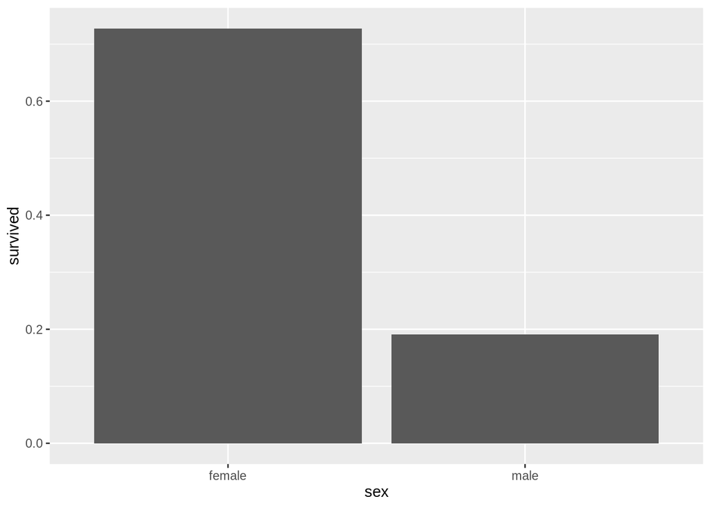

```r
#Answer 1.d.1
#1. What was the survival rates for females and males?

library(ggplot2)

ggplot(titanic3, aes(x = sex, y = survived, fill = survived)) +
geom_bar(stat='summary') +
scale_x_discrete(labels=c("female", "male"))
```

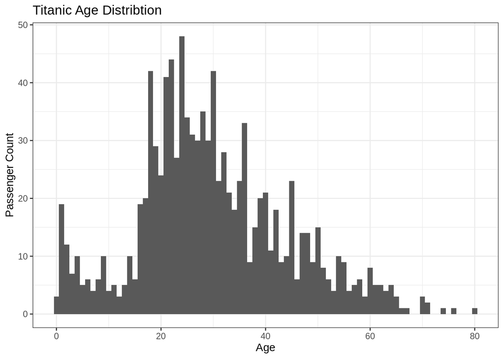

```r
#Answer 1.d.2
#2. What was the age distribution on the Titanic?

ggplot(titanic3, aes(x = age)) +
  theme_bw() +
  geom_histogram(binwidth = 1) +
  labs(y = "Passenger Count",
       x = "Age",
       title = "Titanic Age Distribtion")
```

e)Use the `for` loop and `if` control statements to list the women’s names, age 34 or more that embarked from S (Southampton), on the Titanic.

```r
namesConditional <- for (i in 1:dim(titanic3)[1]) {
  if (is.na(titanic3$age[i])) {
    next
  }

  if (is.na(titanic3$embarked[i])) {
    next
  }

  if (is.na(titanic3$sex[i])) {
    next
  }

  if (titanic3$sex[i] == "female" & titanic3$age[i] >= 34 & titanic3$embarked[i] == "S") {
    print(titanic3$name[i])
  }
}
```

```
## [1] Andrews, Miss. Kornelia Theodosia
## 1307 Levels: Abbing, Mr. Anthony ... Zimmerman, Mr. Leo
## [1] Appleton, Mrs. Edward Dale (Charlotte Lamson)
## 1307 Levels: Abbing, Mr. Anthony ... Zimmerman, Mr. Leo
## [1] Beckwith, Mrs. Richard Leonard (Sallie Monypeny)
## 1307 Levels: Abbing, Mr. Anthony ... Zimmerman, Mr. Leo
## [1] Bissette, Miss. Amelia
## 1307 Levels: Abbing, Mr. Anthony ... Zimmerman, Mr. Leo
## [1] Bonnell, Miss. Elizabeth
## 1307 Levels: Abbing, Mr. Anthony ... Zimmerman, Mr. Leo
## [1] Brown, Mrs. John Murray (Caroline Lane Lamson)
## 1307 Levels: Abbing, Mr. Anthony ... Zimmerman, Mr. Leo
## [1] Carter, Mrs. William Ernest (Lucile Polk)
## 1307 Levels: Abbing, Mr. Anthony ... Zimmerman, Mr. Leo
## [1] Cavendish, Mrs. Tyrell William (Julia Florence Siegel)
```

[output cut: 145 more lines]

## Question 2

A study was conducted on GRE test takers to evaluate the success conditions. The success rate is 25%. A sample of 30 test takers is selected for the study. Use the binomial distribution to calculate the followings:

1. The probability that 10 test takers fail the GRE test:

```r
dbinom(x = 10, size = 30, prob = .75)
```

```
## [1] 1.538811e-06
```

2. The probability of getting at least five test takers succeed in the test

```r
# x >= 5
sum(dbinom(5:30, size = 30, prob = .25))
```

```
## [1] 0.9021304
```

3. The probability of 25 or less fail the test

```r
sum(dbinom(x = 0:25, size = 30, prob = .75))
```

```
## [1] 0.9021304
```

## Question 3

In a shipment of 20 engines, history shows that the probability of any one engine proving unsatisfactory is 0.1

1. Use the Binomial approximation to calculate the probability that more than 10 engines are defective?

```r
#10 < x <= 20
#P. fail = 0.1

1 - pbinom(10, size = 20, prob = 0.1)
```

```
## [1] 7.088606e-07
```

2. Use the Poisson approximation to calculate the probability that at most three engines are defective?

```r
#x <= 3
#P. fail = 0.1
#λ = np = 20 * 0.1 = 2

ppois(3, lambda = 2)
```

```
## [1] 0.8571235
```

2. Use the binomial approximation to calculate the probability that at most three engines are defective?

```r
# 0 <= x <= 3
#P. fail = 0.1

pbinom(3, size = 20, prob = 0.1)
```

```
## [1] 0.8670467
```

3. Compare the results of parts a and b, then illustrate on how well the Poisson probability distribution approximates the Binomial probability distribution.

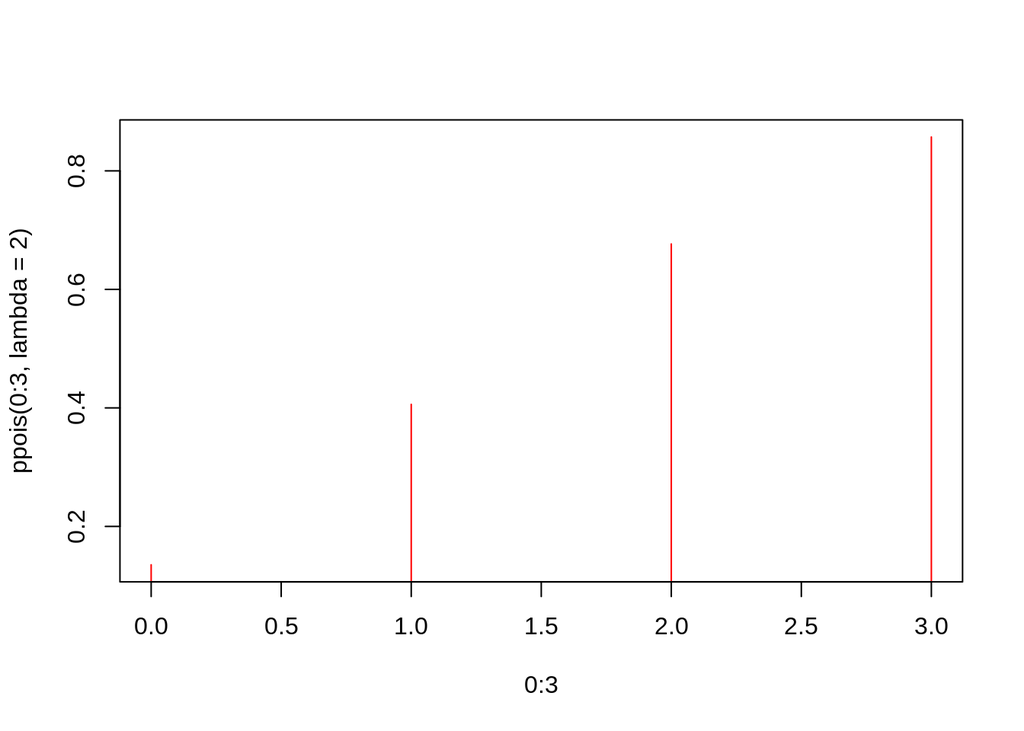

```r
plot(0:3, ppois(0:3, lambda=2), type='h', col = "red")
```

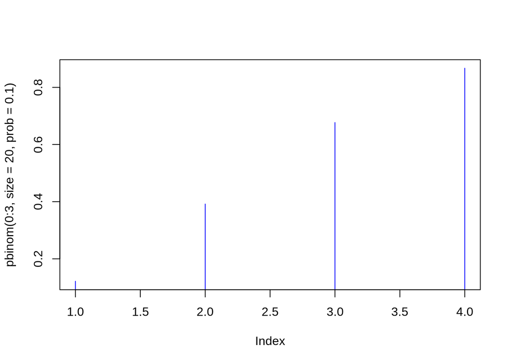

```r
plot(pbinom(0:3, size = 20, prob = 0.1), type='h', col = "blue")
```

```r
par(mfrow = c(1, 2))
```

## Question 4

Write a script in R to compute the following probabilities of a normal random variable with mean 16 and variance 9

1. lies between 14.4 and 20.3 (inclusive)

```r
#sd = sqrt(9) = 3

pnorm(20.3, mean = 16, sd = 3) - pnorm(14.4, mean = 16, sd = 3)
```

```
## [1] 0.6272173
```

2. is greater than 21.8

```r
pnorm(21.8, mean = 16, sd = 3, lower.tail=FALSE)
```

```
## [1] 0.02659757
```

3. is less or equal to 10.5

```r
pnorm(10.5, mean = 16, sd = 3)
```

```
## [1] 0.03337651
```

4. is less than 13 or greater than 19

```r
#x < 13, x > 19

pnorm(13, mean = 16, sd = 3) + (1 - pnorm(19, mean = 16, sd = 3))
```

```
## [1] 0.3173105
```

END of Project #2.